# Project: Wrangling and Analyze Data

|  | tweet_id | timestamp | tweet_source | tweet_text | expanded_urls | rating_numerator | rating_denominator | dog_name | retweet_count | favorite_count | ... | first_image_prediction | first_prediction_cs | first_prediction_is_a_dog | second_image_prediction | second_prediction_cs | second_prediction_is_a_dog | third_image_prediction | third_prediction_cs | third_prediction_is_a_dog | dogtionary_rating |
| --- | --- | --- | --- | --- | --- | --- | --- | --- | --- | --- | --- | --- | --- | --- | --- | --- | --- | --- | --- | --- | --- |
| 315 | 835152434251116546 | 2017-02-24 15:40:31 +0000 | <a href="http://twitter.com/download/iphone" rel="nofollow">Twitter for iPhone</a> | When you're so blinded by your systematic plagiarism that you forget what day it is. 0/10 https://t.co/YbEJPkg4Ag | https://twitter.com/dog_rates/status/835152434251116546/photo/1,https://twitter.com/dog_rates/status/835152434251116546/photo/1,https://... | 0 | 10 | NaN | 3443.0 | 24574.0 | ... | swing | 0.967066 | False | American_Staffordshire_terrier | 0.012731 | True | Staffordshire_bullterrier | 0.007039 | True | NaN |
| 765 | 777885040357281792 | 2016-09-19 15:00:20 +0000 | <a href="http://twitter.com/download/iphone" rel="nofollow">Twitter for iPhone</a> | This is Wesley. He's clearly trespassing. Seems rather h*ckin violent too. Weaponized forehead. 3/10 wouldn't let in https://t.co/pL7wbM... | https://twitter.com/dog_rates/status/777885040357281792/photo/1,https://twitter.com/dog_rates/status/777885040357281792/photo/1 | 3 | 10 | Wesley | 1893.0 | 7078.0 | ... | Afghan_hound | 0.123529 | True | basset | 0.119682 | True | Siberian_husky | 0.108709 | True | NaN |
| 883 | 760252756032651264 | 2016-08-01 23:15:56 +0000 | <a href="http://twitter.com/download/iphone" rel="nofollow">Twitter for iPhone</a> | This is Fido. He can tell the weather. Not good at fetch tho. Never comes when called. 4/10 would probably still pet https://t.co/4gOv2Q... | https://twitter.com/dog_rates/status/760252756032651264/photo/1 | 4 | 10 | Fido | 995.0 | 4338.0 | ... | radio_telescope | 0.155279 | False | dam | 0.154515 | False | crane | 0.098040 | False | NaN |
| 912 | 757596066325864448 | 2016-07-25 15:19:12 +0000 | <a href="http://twitter.com/download/iphone" rel="nofollow">Twitter for iPhone</a> | Here's another picture without a dog in it. Idk why you guys keep sending these. 4/10 just because that's a neat rug https://t.co/mOmnL1... | https://twitter.com/dog_rates/status/757596066325864448/photo/1 | 4 | 10 | NaN | 1219.0 | 4808.0 | ... | doormat | 0.845256 | False | wallet | 0.095718 | False | wool | 0.026072 | False | NaN |
| 1004 | 747816857231626240 | 2016-06-28 15:40:07 +0000 | <a href="http://twitter.com/download/iphone" rel="nofollow">Twitter for iPhone</a> | Viewer discretion is advised. This is a terrible attack in progress. Not even in water (tragic af). 4/10 bad sherk https://t.co/L3U0j14N5R | https://twitter.com/dog_rates/status/747816857231626240/photo/1 | 4 | 10 | NaN | 1316.0 | 5346.0 | ... | Pembroke | 0.768923 | True | Chihuahua | 0.029053 | True | Shetland_sheepdog | 0.029035 | True | NaN |
| 1016 | 746906459439529985 | 2016-06-26 03:22:31 +0000 | <a href="http://twitter.com/download/iphone" rel="nofollow">Twitter for iPhone</a> | PUPDATE: can't see any. Even if I could, I couldn't reach them to pet. 0/10 much disappointment https://t.co/c7WXaB2nqX | https://twitter.com/dog_rates/status/746906459439529985/photo/1 | 0 | 10 | NaN | 336.0 | 3168.0 | ... | traffic_light | 0.470708 | False | fountain | 0.199776 | False | space_shuttle | 0.064807 | False | NaN |
| 1165 | 722974582966214656 | 2016-04-21 02:25:47 +0000 | <a href="http://twitter.com/download/iphone" rel="nofollow">Twitter for iPhone</a> | Happy 4/20 from the squad! 13/10 for all https://t.co/eV1diwds8a | https://twitter.com/dog_rates/status/722974582966214656/photo/1 | 4 | 20 | NaN | 1764.0 | 4493.0 | ... | Great_Dane | 0.246762 | True | Greater_Swiss_Mountain_dog | 0.126131 | True | Weimaraner | 0.085297 | True | NaN |
| 1189 | 718246886998687744 | 2016-04-08 01:19:36 +0000 | <a href="http://twitter.com/download/iphone" rel="nofollow">Twitter for iPhone</a> | This is Alexanderson. He's got a weird ass birth mark. Dreadful at fetch. Won't eat kibble. 3/10 wtf @Target https://t.co/FmxOpf2Sgl | https://twitter.com/dog_rates/status/718246886998687744/photo/1 | 3 | 10 | Alexanderson | 565.0 | 2115.0 | ... | Chihuahua | 0.354488 | True | carton | 0.159672 | False | Siberian_husky | 0.057498 | True | NaN |
| 1219 | 714631576617938945 | 2016-03-29 01:53:39 +0000 | <a href="http://twitter.com/download/iphone" rel="nofollow">Twitter for iPhone</a> | This is Benedict. He's a feisty pup. Needs a brushing. Portable af. Looks very angry actually. 4/10 might not pet https://t.co/3oeFfHjv0Z | https://twitter.com/dog_rates/status/714631576617938945/photo/1 | 4 | 10 | Benedict | 1122.0 | 3571.0 | ... | meerkat | 0.143497 | False | weasel | 0.117402 | False | black-footed_ferret | 0.099933 | False | NaN |
| 1249 | 711306686208872448 | 2016-03-19 21:41:44 +0000 | <a href="http://twitter.com/download/iphone" rel="nofollow">Twitter for iPhone</a> | What hooligan sent in pictures w/out a dog in them? Churlish af. 3/10 just bc that's a neat fluffy bean bag chair https://t.co/wcwoGOkZvz | https://twitter.com/dog_rates/status/711306686208872448/photo/1,https://twitter.com/dog_rates/status/711306686208872448/photo/1 | 3 | 10 | NaN | 819.0 | 3596.0 | ... | leatherback_turtle | 0.280835 | False | loggerhead | 0.123290 | False | Dandie_Dinmont | 0.086792 | True | NaN |
| 1303 | 707420581654872064 | 2016-03-09 04:19:44 +0000 | <a href="http://twitter.com/download/iphone" rel="nofollow">Twitter for iPhone</a> | This is Keurig. He's a rare dog. Laughs like an idiot tho. Head is basically a weapon. Poorly maintained goatee 4/10 https://t.co/xOrUyj... | https://twitter.com/dog_rates/status/707420581654872064/photo/1 | 4 | 10 | Keurig | 789.0 | 2499.0 | ... | ram | 0.518215 | False | kuvasz | 0.149391 | True | Great_Pyrenees | 0.106003 | True | NaN |
| 1314 | 706901761596989440 | 2016-03-07 17:58:08 +0000 | <a href="http://twitter.com/download/iphone" rel="nofollow">Twitter for iPhone</a> | This is Elliot. He's blocking the roadway. Downright rude as hell. Doesn't care that you're already late. 3/10 https://t.co/FMUxir5pYu | https://twitter.com/dog_rates/status/706901761596989440/photo/1 | 3 | 10 | Elliot | 680.0 | 2264.0 | ... | wild_boar | 0.859499 | False | hog | 0.128981 | False | warthog | 0.011318 | False | NaN |
| 1406 | 699088579889332224 | 2016-02-15 04:31:20 +0000 | <a href="http://twitter.com/download/iphone" rel="nofollow">Twitter for iPhone</a> | This is Charl. He's a bully. Chucks that dumbbell around like its nothing. Sharp neck. Exceptionally unfluffy. 3/10 https://t.co/VfLoDZecJ7 | https://twitter.com/dog_rates/status/699088579889332224/photo/1 | 3 | 10 | Charl | 715.0 | 2451.0 | ... | mousetrap | 0.456186 | False | banded_gecko | 0.258677 | False | common_iguana | 0.061783 | False | NaN |
| 1446 | 696490539101908992 | 2016-02-08 00:27:39 +0000 | <a href="http://twitter.com/download/iphone" rel="nofollow">Twitter for iPhone</a> | After reading the comments I may have overestimated this pup. Downgraded to a 1/10. Please forgive me | NaN | 1 | 10 | NaN | 170.0 | 1339.0 | ... | NaN | NaN | NaN | NaN | NaN | NaN | NaN | NaN | NaN | NaN |
| 1459 | 695064344191721472 | 2016-02-04 02:00:27 +0000 | <a href="http://twitter.com/download/iphone" rel="nofollow">Twitter for iPhone</a> | This may be the greatest video I've ever been sent. 4/10 for Charles the puppy, 13/10 overall. (Vid by @stevenxx_) https://t.co/uaJmNgXR2P | https://twitter.com/dog_rates/status/695064344191721472/video/1 | 4 | 10 | NaN | 685.0 | 1771.0 | ... | seat_belt | 0.522211 | False | sunglasses | 0.077552 | False | ice_lolly | 0.051774 | False | NaN |
| 1478 | 693590843962331137 | 2016-01-31 00:25:18 +0000 | <a href="http://twitter.com/download/iphone" rel="nofollow">Twitter for iPhone</a> | Meet Phil. He's big af. Currently destroying this nice family home. Completely uncalled for. 3/10 not a good pupper https://t.co/fShNNhBWYx | https://twitter.com/dog_rates/status/693590843962331137/photo/1 | 3 | 10 | Phil | 2233.0 | 5565.0 | ... | dining_table | 0.383448 | False | grey_fox | 0.103191 | False | Siamese_cat | 0.098256 | False | pupper |
| 1598 | 686035780142297088 | 2016-01-10 04:04:10 +0000 | <a href="http://twitter.com/download/iphone" rel="nofollow">Twitter for iPhone</a> | Yes I do realize a rating of 4/20 would've been fitting. However, it would be unjust to give these cooperative pups that low of a rating | NaN | 4 | 20 | NaN | 138.0 | 1274.0 | ... | NaN | NaN | NaN | NaN | NaN | NaN | NaN | NaN | NaN | NaN |
| 1601 | 686003207160610816 | 2016-01-10 01:54:44 +0000 | <a href="http://twitter.com/download/iphone" rel="nofollow">Twitter for iPhone</a> | This is Hammond. He's a peculiar pup. Loves long walks. Bark barely audible. Too many legs. 3/10 must be rare https://t.co/NOIiRWr5Jf | https://twitter.com/dog_rates/status/686003207160610816/photo/1 | 3 | 10 | Hammond | 735.0 | 2009.0 | ... | damselfly | 0.190786 | False | common_newt | 0.098131 | False | whiptail | 0.088958 | False | NaN |
| 1629 | 684567543613382656 | 2016-01-06 02:49:55 +0000 | <a href="http://twitter.com/download/iphone" rel="nofollow">Twitter for iPhone</a> | This is Bobby. He doesn't give a damn about personal space. Convinced he called shotgun first. 4/10 not the best dog https://t.co/b8XW69... | https://twitter.com/dog_rates/status/684567543613382656/photo/1 | 4 | 10 | Bobby | 1418.0 | 3312.0 | ... | minibus | 0.401942 | False | llama | 0.229145 | False | seat_belt | 0.209393 | False | NaN |
| 1692 | 681302363064414209 | 2015-12-28 02:35:15 +0000 | <a href="http://twitter.com/download/iphone" rel="nofollow">Twitter for iPhone</a> | This is Chuck. He's a neat dog. Very flexible. Trapped in a glass case of emotion. Devastatingly unfluffy 3/10 https://t.co/YqbU9xHV3p | https://twitter.com/dog_rates/status/681302363064414209/photo/1 | 3 | 10 | Chuck | 2072.0 | 4347.0 | ... | frilled_lizard | 0.326259 | False | tailed_frog | 0.104539 | False | axolotl | 0.072479 | False | NaN |
| 1701 | 680940246314430465 | 2015-12-27 02:36:20 +0000 | <a href="http://twitter.com/download/iphone" rel="nofollow">Twitter for iPhone</a> | This is Alice. She's an idiot. 4/10 https://t.co/VQXdwJfkyS | https://twitter.com/dog_rates/status/680940246314430465/photo/1 | 4 | 10 | Alice | 1225.0 | 3544.0 | ... | soft-coated_wheaten_terrier | 0.289598 | True | West_Highland_white_terrier | 0.157195 | True | toy_poodle | 0.074435 | True | NaN |
| 1761 | 678675843183484930 | 2015-12-20 20:38:24 +0000 | <a href="http://twitter.com/download/iphone" rel="nofollow">Twitter for iPhone</a> | Exotic pup here. Tail long af. Throat looks swollen. Might breathe fire. Exceptionally unfluffy 2/10 would still pet https://t.co/a8SqCa... | https://twitter.com/dog_rates/status/678675843183484930/photo/1 | 2 | 10 | NaN | 1680.0 | 3155.0 | ... | maze | 0.339850 | False | streetcar | 0.099688 | False | sundial | 0.084808 | False | NaN |
| 1764 | 678424312106393600 | 2015-12-20 03:58:55 +0000 | <a href="http://twitter.com/download/iphone" rel="nofollow">Twitter for iPhone</a> | This is Crystal. She's a shitty fireman. No sense of urgency. People could be dying Crystal. 2/10 just irresponsible https://t.co/rtMtjS... | https://twitter.com/dog_rates/status/678424312106393600/photo/1 | 2 | 10 | Crystal | 2880.0 | 5916.0 | ... | Maltese_dog | 0.759945 | True | toy_poodle | 0.101194 | True | Shih-Tzu | 0.056037 | True | NaN |
| 1836 | 676098748976615425 | 2015-12-13 17:57:57 +0000 | <a href="http://twitter.com/download/iphone" rel="nofollow">Twitter for iPhone</a> | Extremely rare pup here. Very religious. Always praying. Too many legs. Not overwhelmingly fluffy. Won't bark. 3/10 https://t.co/REyE5YKVBb | https://twitter.com/dog_rates/status/676098748976615425/photo/1 | 3 | 10 | NaN | 1623.0 | 3279.0 | ... | walking_stick | 0.162179 | False | sandal | 0.129086 | False | purse | 0.081412 | False | NaN |
| 1869 | 675153376133427200 | 2015-12-11 03:21:23 +0000 | <a href="http://twitter.com/download/iphone" rel="nofollow">Twitter for iPhone</a> | What kind of person sends in a picture without a dog in it? 1/10 just because that's a nice table https://t.co/RDXCfk8hK0 | https://twitter.com/dog_rates/status/675153376133427200/photo/1 | 1 | 10 | NaN | 2734.0 | 6072.0 | ... | paper_towel | 0.327957 | False | mailbox | 0.096027 | False | seat_belt | 0.034995 | False | NaN |
| 1898 | 674690135443775488 | 2015-12-09 20:40:38 +0000 | <a href="http://twitter.com/download/iphone" rel="nofollow">Twitter for iPhone</a> | Meet Patrick. He's an exotic pup. Jumps great distances for a dog. Always gets injured when I toss him a ball. 3/10 https://t.co/Unz1uNrOzo | https://twitter.com/dog_rates/status/674690135443775488/photo/1 | 3 | 10 | Patrick | 510.0 | 1237.0 | ... | tick | 0.242538 | False | nail | 0.212589 | False | screw | 0.172838 | False | NaN |
| 1920 | 674265582246694913 | 2015-12-08 16:33:36 +0000 | <a href="http://twitter.com/download/iphone" rel="nofollow">Twitter for iPhone</a> | This is Henry. He's a shit dog. Short pointy ears. Leaves trail of pee. Not fluffy. Doesn't come when called. 2/10 https://t.co/Pu9RhfHDEQ | https://twitter.com/dog_rates/status/674265582246694913/photo/1 | 2 | 10 | Henry | 936.0 | 1766.0 | ... | slug | 0.998075 | False | ice_lolly | 0.000984 | False | leafhopper | 0.000097 | False | NaN |
| 1928 | 674045139690631169 | 2015-12-08 01:57:39 +0000 | <a href="http://twitter.com/download/iphone" rel="nofollow">Twitter for iPhone</a> | Herd of wild dogs here. Not sure what they're trying to do. No real goals in life. 3/10 find your purpose puppers https://t.co/t5ih0VrK02 | https://twitter.com/dog_rates/status/674045139690631169/photo/1 | 3 | 10 | NaN | 710.0 | 1520.0 | ... | robin | 0.369661 | False | rhinoceros_beetle | 0.110607 | False | European_fire_salamander | 0.043178 | False | pupper |
| 1940 | 673716320723169284 | 2015-12-07 04:11:02 +0000 | <a href="http://twitter.com/download/iphone" rel="nofollow">Twitter for iPhone</a> | The millennials have spoken and we've decided to immediately demote to a 1/10. Thank you | NaN | 1 | 10 | NaN | 843.0 | 3289.0 | ... | NaN | NaN | NaN | NaN | NaN | NaN | NaN | NaN | NaN | NaN |
| 1941 | 673715861853720576 | 2015-12-07 04:09:13 +0000 | <a href="http://twitter.com/download/iphone" rel="nofollow">Twitter for iPhone</a> | This is a heavily opinionated dog. Loves walls. Nobody knows how the hair works. Always ready for a kiss. 4/10 https://t.co/dFiaKZ9cDl | https://twitter.com/dog_rates/status/673715861853720576/photo/1 | 4 | 10 | NaN | 2303.0 | 3815.0 | ... | suit | 0.404115 | False | bow_tie | 0.294683 | False | Windsor_tie | 0.132701 | False | NaN |
| 1947 | 673700254269775872 | 2015-12-07 03:07:12 +0000 | <a href="http://twitter.com/download/iphone" rel="nofollow">Twitter for iPhone</a> | Large blue dog here. Cool shades. Flipping us off w both hands. Obviously a preteen. 3/10 for rude blue preteen pup https://t.co/mcPd5AFfhA | https://twitter.com/dog_rates/status/673700254269775872/photo/1 | 3 | 10 | NaN | 638.0 | 1532.0 | ... | water_bottle | 0.614536 | False | ashcan | 0.050911 | False | bucket | 0.037432 | False | NaN |
| 2038 | 671550332464455680 | 2015-12-01 04:44:10 +0000 | <a href="http://twitter.com/download/iphone" rel="nofollow">Twitter for iPhone</a> | After 22 minutes of careful deliberation this dog is being demoted to a 1/10. The longer you look at him the more terrifying he becomes | NaN | 1 | 10 | NaN | 229.0 | 967.0 | ... | NaN | NaN | NaN | NaN | NaN | NaN | NaN | NaN | NaN | NaN |
| 2070 | 671122204919246848 | 2015-11-30 00:22:57 +0000 | <a href="http://twitter.com/download/iphone" rel="nofollow">Twitter for iPhone</a> | Two miniature golden retrievers here. Webbed paws. Don't walk very efficiently. Can't catch a tennis ball. 4/10s https://t.co/WzVLdSHJU7 | https://twitter.com/dog_rates/status/671122204919246848/photo/1 | 4 | 10 | NaN | 2763.0 | 3729.0 | ... | goose | 0.351957 | False | Chihuahua | 0.101228 | True | hen | 0.065818 | False | NaN |
| 2076 | 670838202509447168 | 2015-11-29 05:34:25 +0000 | <a href="http://twitter.com/download/iphone" rel="nofollow">Twitter for iPhone</a> | Pink dogs here. Unreasonably long necks. Left guy has only 1 leg. Quite nimble. Don't bark tho 4/10s would still pet https://t.co/QY5uvM... | https://twitter.com/dog_rates/status/670838202509447168/photo/1 | 4 | 10 | NaN | 758.0 | 1189.0 | ... | flamingo | 0.992710 | False | coral_fungus | 0.003491 | False | stinkhorn | 0.001859 | False | NaN |
| 2079 | 670826280409919488 | 2015-11-29 04:47:03 +0000 | <a href="http://twitter.com/download/iphone" rel="nofollow">Twitter for iPhone</a> | Scary dog here. Too many legs. Extra tail. Not soft, let alone fluffy. Won't bark. Moves sideways. Has weapon. 2/10 https://t.co/XOPXCSXiUT | https://twitter.com/dog_rates/status/670826280409919488/photo/1 | 2 | 10 | NaN | 4485.0 | 5961.0 | ... | scorpion | 0.927956 | False | tarantula | 0.021631 | False | wolf_spider | 0.014837 | False | NaN |
| 2091 | 670783437142401025 | 2015-11-29 01:56:48 +0000 | <a href="http://twitter.com/download/iphone" rel="nofollow">Twitter for iPhone</a> | Flamboyant pup here. Probably poisonous. Won't eat kibble. Doesn't bark. Slow af. Petting doesn't look fun. 1/10 https://t.co/jxukeh2BeO | https://twitter.com/dog_rates/status/670783437142401025/photo/1 | 1 | 10 | NaN | 431.0 | 872.0 | ... | lacewing | 0.381955 | False | sulphur_butterfly | 0.106810 | False | leafhopper | 0.068347 | False | NaN |
| 2136 | 670055038660800512 | 2015-11-27 01:42:24 +0000 | <a href="http://twitter.com/download/iphone" rel="nofollow">Twitter for iPhone</a> | This is Tommy. He's a cool dog. Hard not to step on. Won't let go of seashell. Not fast by any means. 3/10 https://t.co/0gY6XTOpn3 | https://twitter.com/dog_rates/status/670055038660800512/photo/1 | 3 | 10 | Tommy | 357.0 | 716.0 | ... | snail | 0.563631 | False | slug | 0.296649 | False | bolete | 0.031839 | False | NaN |
| 2183 | 668989615043424256 | 2015-11-24 03:08:48 +0000 | <a href="http://twitter.com/download/iphone" rel="nofollow">Twitter for iPhone</a> | This is Bernie. He's taking his Halloween costume very seriously. Wants to be baked. 3/10 not a good idea Bernie smh https://t.co/1zBp1m... | https://twitter.com/dog_rates/status/668989615043424256/photo/1 | 3 | 10 | Bernie | 356.0 | 726.0 | ... | pug | 0.917326 | True | waffle_iron | 0.014918 | False | Chihuahua | 0.013524 | True | NaN |
| 2186 | 668981893510119424 | 2015-11-24 02:38:07 +0000 | <a href="http://twitter.com/download/iphone" rel="nofollow">Twitter for iPhone</a> | Unique dog here. Oddly shaped tail. Long pink front legs. I don't think dogs breath underwater sos. 4/10 bad owner https://t.co/0EJXxE9UxW | https://twitter.com/dog_rates/status/668981893510119424/photo/1 | 4 | 10 | NaN | 340.0 | 573.0 | ... | jellyfish | 0.447246 | False | coral_reef | 0.238625 | False | goldfish | 0.040227 | False | NaN |
| 2202 | 668643542311546881 | 2015-11-23 04:13:37 +0000 | <a href="http://twitter.com/download/iphone" rel="nofollow">Twitter for iPhone</a> | Fascinating dog here. Loves beach. Oddly long nose for dog. Massive ass paws. Hard to cuddle w. 3/10 would still pet https://t.co/IiSdmh... | https://twitter.com/dog_rates/status/668643542311546881/photo/1 | 3 | 10 | NaN | 576.0 | 939.0 | ... | common_iguana | 0.483972 | False | frilled_lizard | 0.111377 | False | sandbar | 0.078983 | False | NaN |
| 2222 | 668466899341221888 | 2015-11-22 16:31:42 +0000 | <a href="http://twitter.com/download/iphone" rel="nofollow">Twitter for iPhone</a> | Here is a mother dog caring for her pups. Snazzy red mohawk. Doesn't wag tail. Pups look confused. Overall 4/10 https://t.co/YOHe6lf09m | https://twitter.com/dog_rates/status/668466899341221888/photo/1 | 4 | 10 | NaN | 560.0 | 936.0 | ... | shopping_basket | 0.398361 | False | hamper | 0.363222 | False | bassinet | 0.084173 | False | NaN |
| 2237 | 668142349051129856 | 2015-11-21 19:02:04 +0000 | <a href="http://twitter.com/download/iphone" rel="nofollow">Twitter for iPhone</a> | This lil pup is Oliver. Hops around. Has wings but doesn't fly (lame). Annoying chirp. Won't catch tennis balls 2/10 https://t.co/DnhUw0... | https://twitter.com/dog_rates/status/668142349051129856/photo/1 | 2 | 10 | NaN | 306.0 | 592.0 | ... | Angora | 0.918834 | False | hen | 0.037793 | False | wood_rabbit | 0.011015 | False | NaN |
| 2239 | 667937095915278337 | 2015-11-21 05:26:27 +0000 | <a href="http://twitter.com/download/iphone" rel="nofollow">Twitter for iPhone</a> | This dog resembles a baked potato. Bed looks uncomfortable. No tail. Comes with butter tho. 3/10 petting still fun https://t.co/x89NSCEZCq | https://twitter.com/dog_rates/status/667937095915278337/photo/1 | 3 | 10 | NaN | 866.0 | 1356.0 | ... | hamster | 0.172078 | False | guinea_pig | 0.094924 | False | Band_Aid | 0.059995 | False | NaN |
| 2246 | 667878741721415682 | 2015-11-21 01:34:35 +0000 | <a href="http://twitter.com/download/iphone" rel="nofollow">Twitter for iPhone</a> | This is Tedrick. He lives on the edge. Needs someone to hit the gas tho. Other than that he's a baller. 10&amp;2/10 https://t.co/LvP1TTYSCN | https://twitter.com/dog_rates/status/667878741721415682/photo/1 | 2 | 10 | Tedrick | 127.0 | 409.0 | ... | seat_belt | 0.200373 | False | miniature_pinscher | 0.106003 | True | schipperke | 0.104733 | True | NaN |
| 2261 | 667549055577362432 | 2015-11-20 03:44:31 +0000 | <a href="http://twitter.com" rel="nofollow">Twitter Web Client</a> | Never seen dog like this. Breathes heavy. Tilts head in a pattern. No bark. Shitty at fetch. Not even cordless. 1/10 https://t.co/i9iSGN... | https://twitter.com/dog_rates/status/667549055577362432/photo/1 | 1 | 10 | NaN | 2454.0 | 6138.0 | ... | electric_fan | 0.984377 | False | spotlight | 0.007737 | False | lampshade | 0.001901 | False | NaN |
| 2288 | 667176164155375616 | 2015-11-19 03:02:47 +0000 | <a href="http://twitter.com/download/iphone" rel="nofollow">Twitter for iPhone</a> | These are strange dogs. All have toupees. Long neck for dogs. In a shed of sorts? Work in groups? 4/10 still petable https://t.co/PZxSar... | https://twitter.com/dog_rates/status/667176164155375616/photo/1 | 4 | 10 | NaN | 484.0 | 640.0 | ... | soft-coated_wheaten_terrier | 0.318981 | True | Lakeland_terrier | 0.215218 | True | toy_poodle | 0.106014 | True | NaN |
| 2305 | 666837028449972224 | 2015-11-18 04:35:11 +0000 | <a href="http://twitter.com/download/iphone" rel="nofollow">Twitter for iPhone</a> | My goodness. Very rare dog here. Large. Tail dangerous. Kinda fat. Only eats leaves. Doesn't come when called 3/10 https://t.co/xYGdBrMS9h | https://twitter.com/dog_rates/status/666837028449972224/photo/1 | 3 | 10 | NaN | 584.0 | 857.0 | ... | triceratops | 0.442113 | False | armadillo | 0.114071 | False | common_iguana | 0.043255 | False | NaN |
| 2310 | 666786068205871104 | 2015-11-18 01:12:41 +0000 | <a href="http://twitter.com/download/iphone" rel="nofollow">Twitter for iPhone</a> | Unfamiliar with this breed. Ears pointy af. Won't let go of seashell. Won't eat kibble. Not very fast. Bad dog 2/10 https://t.co/EIn5kElY1S | https://twitter.com/dog_rates/status/666786068205871104/photo/1 | 2 | 10 | NaN | 521.0 | 800.0 | ... | snail | 0.999888 | False | slug | 0.000055 | False | acorn | 0.000026 | False | NaN |
| 2316 | 666649482315059201 | 2015-11-17 16:09:56 +0000 | <a href="http://twitter.com/download/iphone" rel="nofollow">Twitter for iPhone</a> | Cool dog. Enjoys couch. Low monotone bark. Very nice kicks. Pisses milk (must be rare). Can't go down stairs. 4/10 https://t.co/vXMKrJC81s | https://twitter.com/dog_rates/status/666649482315059201/photo/1 | 4 | 10 | NaN | 608.0 | 923.0 | ... | Border_collie | 0.447803 | True | English_springer | 0.170497 | True | collie | 0.139206 | True | NaN |
| 2326 | 666411507551481857 | 2015-11-17 00:24:19 +0000 | <a href="http://twitter.com/download/iphone" rel="nofollow">Twitter for iPhone</a> | This is quite the dog. Gets really excited when not in water. Not very soft tho. Bad at fetch. Can't do tricks. 2/10 https://t.co/aMCTNW... | https://twitter.com/dog_rates/status/666411507551481857/photo/1 | 2 | 10 | NaN | 339.0 | 459.0 | ... | coho | 0.404640 | False | barracouta | 0.271485 | False | gar | 0.189945 | False | NaN |
| 2334 | 666293911632134144 | 2015-11-16 16:37:02 +0000 | <a href="http://twitter.com/download/iphone" rel="nofollow">Twitter for iPhone</a> | This is a funny dog. Weird toes. Won't come down. Loves branch. Refuses to eat his food. Hard to cuddle with. 3/10 https://t.co/IIXis0zta0 | https://twitter.com/dog_rates/status/666293911632134144/photo/1 | 3 | 10 | NaN | 368.0 | 522.0 | ... | three-toed_sloth | 0.914671 | False | otter | 0.015250 | False | great_grey_owl | 0.013207 | False | NaN |
| 2335 | 666287406224695296 | 2015-11-16 16:11:11 +0000 | <a href="http://twitter.com/download/iphone" rel="nofollow">Twitter for iPhone</a> | This is an Albanian 3 1/2 legged Episcopalian. Loves well-polished hardwood flooring. Penis on the collar. 9/10 https://t.co/d9NcXFKwLv | https://twitter.com/dog_rates/status/666287406224695296/photo/1 | 1 | 2 | NaN | 71.0 | 152.0 | ... | Maltese_dog | 0.857531 | True | toy_poodle | 0.063064 | True | miniature_poodle | 0.025581 | True | NaN |
| 2338 | 666104133288665088 | 2015-11-16 04:02:55 +0000 | <a href="http://twitter.com/download/iphone" rel="nofollow">Twitter for iPhone</a> | Not familiar with this breed. No tail (weird). Only 2 legs. Doesn't bark. Surprisingly quick. Shits eggs. 1/10 https://t.co/Asgdc6kuLX | https://twitter.com/dog_rates/status/666104133288665088/photo/1 | 1 | 10 | NaN | 6871.0 | 14765.0 | ... | hen | 0.965932 | False | cock | 0.033919 | False | partridge | 0.000052 | False | NaN |
| 2349 | 666051853826850816 | 2015-11-16 00:35:11 +0000 | <a href="http://twitter.com/download/iphone" rel="nofollow">Twitter for iPhone</a> | This is an odd dog. Hard on the outside but loving on the inside. Petting still fun. Doesn't play catch well. 2/10 https://t.co/v5A4vzSDdc | https://twitter.com/dog_rates/status/666051853826850816/photo/1 | 2 | 10 | NaN | 879.0 | 1253.0 | ... | box_turtle | 0.933012 | False | mud_turtle | 0.045885 | False | terrapin | 0.017885 | False | NaN |

54 rows × 21 columns

```python
#  check denominator odd values

twitter_master_df.rating_denominator.value_counts()
```

```
10    2140
11       2
20       2
15       1
2        1
Name: rating_denominator, dtype: int64
```

```python
#  display 6 values greater than 10 to check

twitter_master_df.query('rating_denominator > 10')
```

|  | tweet_id | timestamp | tweet_source | tweet_text | expanded_urls | rating_numerator | rating_denominator | dog_name | retweet_count | favorite_count | ... | first_image_prediction | first_prediction_cs | first_prediction_is_a_dog | second_image_prediction | second_prediction_cs | second_prediction_is_a_dog | third_image_prediction | third_prediction_cs | third_prediction_is_a_dog | dogtionary_rating |
| --- | --- | --- | --- | --- | --- | --- | --- | --- | --- | --- | --- | --- | --- | --- | --- | --- | --- | --- | --- | --- | --- |
| 342 | 832088576586297345 | 2017-02-16 04:45:50 +0000 | <a href="http://twitter.com/download/iphone" rel="nofollow">Twitter for iPhone</a> | @docmisterio account started on 11/15/15 | NaN | 11 | 15 | NaN | 3.0 | 72.0 | ... | NaN | NaN | NaN | NaN | NaN | NaN | NaN | NaN | NaN | NaN |
| 1068 | 740373189193256964 | 2016-06-08 02:41:38 +0000 | <a href="http://twitter.com/download/iphone" rel="nofollow">Twitter for iPhone</a> | After so many requests, this is Bretagne. She was the last surviving 9/11 search dog, and our second ever 14/10. RIP https://t.co/XAVDND... | https://twitter.com/dog_rates/status/740373189193256964/photo/1,https://twitter.com/dog_rates/status/740373189193256964/photo/1,https://... | 9 | 11 | NaN | 9220.0 | 20648.0 | ... | golden_retriever | 0.807644 | True | kuvasz | 0.101286 | True | Labrador_retriever | 0.023785 | True | NaN |
| 1165 | 722974582966214656 | 2016-04-21 02:25:47 +0000 | <a href="http://twitter.com/download/iphone" rel="nofollow">Twitter for iPhone</a> | Happy 4/20 from the squad! 13/10 for all https://t.co/eV1diwds8a | https://twitter.com/dog_rates/status/722974582966214656/photo/1 | 4 | 20 | NaN | 1764.0 | 4493.0 | ... | Great_Dane | 0.246762 | True | Greater_Swiss_Mountain_dog | 0.126131 | True | Weimaraner | 0.085297 | True | NaN |
| 1598 | 686035780142297088 | 2016-01-10 04:04:10 +0000 | <a href="http://twitter.com/download/iphone" rel="nofollow">Twitter for iPhone</a> | Yes I do realize a rating of 4/20 would've been fitting. However, it would be unjust to give these cooperative pups that low of a rating | NaN | 4 | 20 | NaN | 138.0 | 1274.0 | ... | NaN | NaN | NaN | NaN | NaN | NaN | NaN | NaN | NaN | NaN |
| 1662 | 682962037429899265 | 2016-01-01 16:30:13 +0000 | <a href="http://twitter.com/download/iphone" rel="nofollow">Twitter for iPhone</a> | This is Darrel. He just robbed a 7/11 and is in a high speed police chase. Was just spotted by the helicopter 10/10 https://t.co/7EsP8LmSp5 | https://twitter.com/dog_rates/status/682962037429899265/photo/1 | 7 | 11 | Darrel | 15043.0 | 26239.0 | ... | dingo | 0.278600 | False | Chihuahua | 0.155207 | True | loupe | 0.153598 | False | NaN |

5 rows × 21 columns

```python
#  tweet id: 832088576586297345

twitter_master_df.query('tweet_id == 832088576586297345')
```

|  | tweet_id | timestamp | tweet_source | tweet_text | expanded_urls | rating_numerator | rating_denominator | dog_name | retweet_count | favorite_count | ... | first_image_prediction | first_prediction_cs | first_prediction_is_a_dog | second_image_prediction | second_prediction_cs | second_prediction_is_a_dog | third_image_prediction | third_prediction_cs | third_prediction_is_a_dog | dogtionary_rating |
| --- | --- | --- | --- | --- | --- | --- | --- | --- | --- | --- | --- | --- | --- | --- | --- | --- | --- | --- | --- | --- | --- |
| 342 | 832088576586297345 | 2017-02-16 04:45:50 +0000 | <a href="http://twitter.com/download/iphone" rel="nofollow">Twitter for iPhone</a> | @docmisterio account started on 11/15/15 | NaN | 11 | 15 | NaN | 3.0 | 72.0 | ... | NaN | NaN | NaN | NaN | NaN | NaN | NaN | NaN | NaN | NaN |

1 rows × 21 columns

Not a dog related tweet

```python
#  drop row

twitter_master_df.drop(twitter_master_df.query('tweet_id == 832088576586297345').index, inplace=True)
```

```python
#  tweet id: 670842764863651840 ##CHECK##

twitter_master_df.query('tweet_id == 832088576586297345')
```

|  | tweet_id | timestamp | tweet_source | tweet_text | expanded_urls | rating_numerator | rating_denominator | dog_name | retweet_count | favorite_count | ... | first_image_prediction | first_prediction_cs | first_prediction_is_a_dog | second_image_prediction | second_prediction_cs | second_prediction_is_a_dog | third_image_prediction | third_prediction_cs | third_prediction_is_a_dog | dogtionary_rating |
| --- | --- | --- | --- | --- | --- | --- | --- | --- | --- | --- | --- | --- | --- | --- | --- | --- | --- | --- | --- | --- | --- |

0 rows × 21 columns

```python
#  tweet id: 740373189193256964

twitter_master_df.query('tweet_id == 740373189193256964')
```

|  | tweet_id | timestamp | tweet_source | tweet_text | expanded_urls | rating_numerator | rating_denominator | dog_name | retweet_count | favorite_count | ... | first_image_prediction | first_prediction_cs | first_prediction_is_a_dog | second_image_prediction | second_prediction_cs | second_prediction_is_a_dog | third_image_prediction | third_prediction_cs | third_prediction_is_a_dog | dogtionary_rating |
| --- | --- | --- | --- | --- | --- | --- | --- | --- | --- | --- | --- | --- | --- | --- | --- | --- | --- | --- | --- | --- | --- |
| 1068 | 740373189193256964 | 2016-06-08 02:41:38 +0000 | <a href="http://twitter.com/download/iphone" rel="nofollow">Twitter for iPhone</a> | After so many requests, this is Bretagne. She was the last surviving 9/11 search dog, and our second ever 14/10. RIP https://t.co/XAVDND... | https://twitter.com/dog_rates/status/740373189193256964/photo/1,https://twitter.com/dog_rates/status/740373189193256964/photo/1,https://... | 9 | 11 | NaN | 9220.0 | 20648.0 | ... | golden_retriever | 0.807644 | True | kuvasz | 0.101286 | True | Labrador_retriever | 0.023785 | True | NaN |

1 rows × 21 columns

```python
#  wrong rating when compared to tweet text --> update to correct rating 14/10

twitter_master_df.loc[twitter_master_df.query('tweet_id == 740373189193256964').index, \
                      ['rating_numerator','rating_denominator']] = 14,10
```

```python
#  tweet id: 670842764863651840 ##CHECK##

twitter_master_df.query('tweet_id == 740373189193256964')
```

|  | tweet_id | timestamp | tweet_source | tweet_text | expanded_urls | rating_numerator | rating_denominator | dog_name | retweet_count | favorite_count | ... | first_image_prediction | first_prediction_cs | first_prediction_is_a_dog | second_image_prediction | second_prediction_cs | second_prediction_is_a_dog | third_image_prediction | third_prediction_cs | third_prediction_is_a_dog | dogtionary_rating |
| --- | --- | --- | --- | --- | --- | --- | --- | --- | --- | --- | --- | --- | --- | --- | --- | --- | --- | --- | --- | --- | --- |
| 1068 | 740373189193256964 | 2016-06-08 02:41:38 +0000 | <a href="http://twitter.com/download/iphone" rel="nofollow">Twitter for iPhone</a> | After so many requests, this is Bretagne. She was the last surviving 9/11 search dog, and our second ever 14/10. RIP https://t.co/XAVDND... | https://twitter.com/dog_rates/status/740373189193256964/photo/1,https://twitter.com/dog_rates/status/740373189193256964/photo/1,https://... | 14 | 10 | NaN | 9220.0 | 20648.0 | ... | golden_retriever | 0.807644 | True | kuvasz | 0.101286 | True | Labrador_retriever | 0.023785 | True | NaN |

1 rows × 21 columns

```python
#  tweet id: 722974582966214656

twitter_master_df.query('tweet_id == 722974582966214656')
```

|  | tweet_id | timestamp | tweet_source | tweet_text | expanded_urls | rating_numerator | rating_denominator | dog_name | retweet_count | favorite_count | ... | first_image_prediction | first_prediction_cs | first_prediction_is_a_dog | second_image_prediction | second_prediction_cs | second_prediction_is_a_dog | third_image_prediction | third_prediction_cs | third_prediction_is_a_dog | dogtionary_rating |
| --- | --- | --- | --- | --- | --- | --- | --- | --- | --- | --- | --- | --- | --- | --- | --- | --- | --- | --- | --- | --- | --- |
| 1165 | 722974582966214656 | 2016-04-21 02:25:47 +0000 | <a href="http://twitter.com/download/iphone" rel="nofollow">Twitter for iPhone</a> | Happy 4/20 from the squad! 13/10 for all https://t.co/eV1diwds8a | https://twitter.com/dog_rates/status/722974582966214656/photo/1 | 4 | 20 | NaN | 1764.0 | 4493.0 | ... | Great_Dane | 0.246762 | True | Greater_Swiss_Mountain_dog | 0.126131 | True | Weimaraner | 0.085297 | True | NaN |

1 rows × 21 columns

```python
#  wrong rating when compared to tweet text --> update to correct rating 13/10

twitter_master_df.loc[twitter_master_df.query('tweet_id == 722974582966214656').index, \
                      ['rating_numerator','rating_denominator']] = 13,10
```

```python
#  tweet id: 722974582966214656 ##CHECK##

twitter_master_df.query('tweet_id == 722974582966214656')
```

|  | tweet_id | timestamp | tweet_source | tweet_text | expanded_urls | rating_numerator | rating_denominator | dog_name | retweet_count | favorite_count | ... | first_image_prediction | first_prediction_cs | first_prediction_is_a_dog | second_image_prediction | second_prediction_cs | second_prediction_is_a_dog | third_image_prediction | third_prediction_cs | third_prediction_is_a_dog | dogtionary_rating |
| --- | --- | --- | --- | --- | --- | --- | --- | --- | --- | --- | --- | --- | --- | --- | --- | --- | --- | --- | --- | --- | --- |
| 1165 | 722974582966214656 | 2016-04-21 02:25:47 +0000 | <a href="http://twitter.com/download/iphone" rel="nofollow">Twitter for iPhone</a> | Happy 4/20 from the squad! 13/10 for all https://t.co/eV1diwds8a | https://twitter.com/dog_rates/status/722974582966214656/photo/1 | 13 | 10 | NaN | 1764.0 | 4493.0 | ... | Great_Dane | 0.246762 | True | Greater_Swiss_Mountain_dog | 0.126131 | True | Weimaraner | 0.085297 | True | NaN |

1 rows × 21 columns

```python
#  tweet id: 686035780142297088

twitter_master_df.query('tweet_id == 686035780142297088')
```

|  | tweet_id | timestamp | tweet_source | tweet_text | expanded_urls | rating_numerator | rating_denominator | dog_name | retweet_count | favorite_count | ... | first_image_prediction | first_prediction_cs | first_prediction_is_a_dog | second_image_prediction | second_prediction_cs | second_prediction_is_a_dog | third_image_prediction | third_prediction_cs | third_prediction_is_a_dog | dogtionary_rating |
| --- | --- | --- | --- | --- | --- | --- | --- | --- | --- | --- | --- | --- | --- | --- | --- | --- | --- | --- | --- | --- | --- |
| 1598 | 686035780142297088 | 2016-01-10 04:04:10 +0000 | <a href="http://twitter.com/download/iphone" rel="nofollow">Twitter for iPhone</a> | Yes I do realize a rating of 4/20 would've been fitting. However, it would be unjust to give these cooperative pups that low of a rating | NaN | 4 | 20 | NaN | 138.0 | 1274.0 | ... | NaN | NaN | NaN | NaN | NaN | NaN | NaN | NaN | NaN | NaN |

1 rows × 21 columns

reply to the previous tweet

```python
#  drop row

twitter_master_df.drop(twitter_master_df.query('tweet_id == 686035780142297088').index, inplace=True)
```

```python
#  tweet id: 722974582966214656 ##CHECK##

twitter_master_df.query('tweet_id == 686035780142297088')
```

|  | tweet_id | timestamp | tweet_source | tweet_text | expanded_urls | rating_numerator | rating_denominator | dog_name | retweet_count | favorite_count | ... | first_image_prediction | first_prediction_cs | first_prediction_is_a_dog | second_image_prediction | second_prediction_cs | second_prediction_is_a_dog | third_image_prediction | third_prediction_cs | third_prediction_is_a_dog | dogtionary_rating |
| --- | --- | --- | --- | --- | --- | --- | --- | --- | --- | --- | --- | --- | --- | --- | --- | --- | --- | --- | --- | --- | --- |

0 rows × 21 columns

```python
#  tweet id: 682962037429899265

twitter_master_df.query('tweet_id == 682962037429899265')
```

|  | tweet_id | timestamp | tweet_source | tweet_text | expanded_urls | rating_numerator | rating_denominator | dog_name | retweet_count | favorite_count | ... | first_image_prediction | first_prediction_cs | first_prediction_is_a_dog | second_image_prediction | second_prediction_cs | second_prediction_is_a_dog | third_image_prediction | third_prediction_cs | third_prediction_is_a_dog | dogtionary_rating |
| --- | --- | --- | --- | --- | --- | --- | --- | --- | --- | --- | --- | --- | --- | --- | --- | --- | --- | --- | --- | --- | --- |
| 1662 | 682962037429899265 | 2016-01-01 16:30:13 +0000 | <a href="http://twitter.com/download/iphone" rel="nofollow">Twitter for iPhone</a> | This is Darrel. He just robbed a 7/11 and is in a high speed police chase. Was just spotted by the helicopter 10/10 https://t.co/7EsP8LmSp5 | https://twitter.com/dog_rates/status/682962037429899265/photo/1 | 7 | 11 | Darrel | 15043.0 | 26239.0 | ... | dingo | 0.2786 | False | Chihuahua | 0.155207 | True | loupe | 0.153598 | False | NaN |

1 rows × 21 columns

```python
#  wrong rating when compared to tweet text --> update to correct rating 10/10

twitter_master_df.loc[twitter_master_df.query('tweet_id == 682962037429899265').index, \
                      ['rating_numerator','rating_denominator']] = 10,10
```

```python
#  tweet id: 722974582966214656 ##CHECK##

twitter_master_df.query('tweet_id == 682962037429899265')
```

|  | tweet_id | timestamp | tweet_source | tweet_text | expanded_urls | rating_numerator | rating_denominator | dog_name | retweet_count | favorite_count | ... | first_image_prediction | first_prediction_cs | first_prediction_is_a_dog | second_image_prediction | second_prediction_cs | second_prediction_is_a_dog | third_image_prediction | third_prediction_cs | third_prediction_is_a_dog | dogtionary_rating |
| --- | --- | --- | --- | --- | --- | --- | --- | --- | --- | --- | --- | --- | --- | --- | --- | --- | --- | --- | --- | --- | --- |
| 1662 | 682962037429899265 | 2016-01-01 16:30:13 +0000 | <a href="http://twitter.com/download/iphone" rel="nofollow">Twitter for iPhone</a> | This is Darrel. He just robbed a 7/11 and is in a high speed police chase. Was just spotted by the helicopter 10/10 https://t.co/7EsP8LmSp5 | https://twitter.com/dog_rates/status/682962037429899265/photo/1 | 10 | 10 | Darrel | 15043.0 | 26239.0 | ... | dingo | 0.2786 | False | Chihuahua | 0.155207 | True | loupe | 0.153598 | False | NaN |

1 rows × 21 columns

```python
#  check the 2 value

twitter_master_df.query('rating_denominator == 2')
```

|  | tweet_id | timestamp | tweet_source | tweet_text | expanded_urls | rating_numerator | rating_denominator | dog_name | retweet_count | favorite_count | ... | first_image_prediction | first_prediction_cs | first_prediction_is_a_dog | second_image_prediction | second_prediction_cs | second_prediction_is_a_dog | third_image_prediction | third_prediction_cs | third_prediction_is_a_dog | dogtionary_rating |
| --- | --- | --- | --- | --- | --- | --- | --- | --- | --- | --- | --- | --- | --- | --- | --- | --- | --- | --- | --- | --- | --- |
| 2335 | 666287406224695296 | 2015-11-16 16:11:11 +0000 | <a href="http://twitter.com/download/iphone" rel="nofollow">Twitter for iPhone</a> | This is an Albanian 3 1/2 legged Episcopalian. Loves well-polished hardwood flooring. Penis on the collar. 9/10 https://t.co/d9NcXFKwLv | https://twitter.com/dog_rates/status/666287406224695296/photo/1 | 1 | 2 | NaN | 71.0 | 152.0 | ... | Maltese_dog | 0.857531 | True | toy_poodle | 0.063064 | True | miniature_poodle | 0.025581 | True | NaN |

1 rows × 21 columns

```python
#  wrong rating when compared to tweet text --> update to correct rating 9/10

twitter_master_df.loc[twitter_master_df.query('tweet_id == 666287406224695296').index, \
                      ['rating_numerator','rating_denominator']] = 9,10
```

```python
#  tweet id: 666287406224695296 ##CHECK##

twitter_master_df.query('tweet_id == 666287406224695296')
```

|  | tweet_id | timestamp | tweet_source | tweet_text | expanded_urls | rating_numerator | rating_denominator | dog_name | retweet_count | favorite_count | ... | first_image_prediction | first_prediction_cs | first_prediction_is_a_dog | second_image_prediction | second_prediction_cs | second_prediction_is_a_dog | third_image_prediction | third_prediction_cs | third_prediction_is_a_dog | dogtionary_rating |
| --- | --- | --- | --- | --- | --- | --- | --- | --- | --- | --- | --- | --- | --- | --- | --- | --- | --- | --- | --- | --- | --- |
| 2335 | 666287406224695296 | 2015-11-16 16:11:11 +0000 | <a href="http://twitter.com/download/iphone" rel="nofollow">Twitter for iPhone</a> | This is an Albanian 3 1/2 legged Episcopalian. Loves well-polished hardwood flooring. Penis on the collar. 9/10 https://t.co/d9NcXFKwLv | https://twitter.com/dog_rates/status/666287406224695296/photo/1 | 9 | 10 | NaN | 71.0 | 152.0 | ... | Maltese_dog | 0.857531 | True | toy_poodle | 0.063064 | True | miniature_poodle | 0.025581 | True | NaN |

1 rows × 21 columns

#### Test

```python
#  check rating_numerator odd values

twitter_master_df.rating_numerator.value_counts()
```

```
12    496
10    444
11    431
13    307
9     155
8      98
7      53
14     43
5      34
6      32
3      18
4      15
2       9
1       7
0       2
Name: rating_numerator, dtype: int64
```

```python
#  check rating_denominator odd values

twitter_master_df.rating_denominator.value_counts()
```

```
10    2144
Name: rating_denominator, dtype: int64
```

### Quality Issue #10: Strange predictions in P1, P2, P3 like: cliff , spatula, barrow, minibus, etc. to be assessed

« back to list

#### Define

check the data sanity for predicted images and identify any false positives or true negatives, adjust values as per findings

#### Code

```python
#  change all values in the columns to low caps for consistancy

twitter_master_df['first_image_prediction'] = twitter_master_df['first_image_prediction'].str.lower()
twitter_master_df['second_image_prediction'] = twitter_master_df['second_image_prediction'].str.lower()
twitter_master_df['third_image_prediction'] = twitter_master_df['third_image_prediction'].str.lower()
```

```python
#  compile false predictions check list

false_predictions = twitter_master_df.query('first_prediction_is_a_dog == False')['first_image_prediction'].unique()
false_predictions = np.append(false_predictions,(twitter_master_df.query('second_prediction_is_a_dog == False')['second_image_prediction'].unique()))
false_predictions = np.append(false_predictions,(twitter_master_df.query('third_prediction_is_a_dog == False')['third_image_prediction'].unique()))

# drop duplicates to create a unique false list

false_unique = np.unique(false_predictions)
```

```python
#  compile true predictions check list

true_predictions = twitter_master_df.query('first_prediction_is_a_dog == True')['first_image_prediction'].unique()
true_predictions = np.append(true_predictions,(twitter_master_df.query('second_prediction_is_a_dog == True')['second_image_prediction'].unique()))
true_predictions = np.append(true_predictions,(twitter_master_df.query('third_prediction_is_a_dog == True')['third_image_prediction'].unique()))

# drop duplicates to create a unique true list

true_unique = np.unique(true_predictions)
```

```python
#  compare true and false arrays and identify false positives or true negatives

compare_false_true = np.in1d(false_unique,true_unique)
compare_false_true.sum()
```

```
1
```

```python
#  locate index of value appearing in true and false

np.where(compare_false_true)
```

```
(array([85]),)
```

```python
# locate value at index 85

false_unique[85]
```

```
'cardigan'
```

```python
twitter_master_df.query('first_image_prediction == "cardigan" and first_prediction_is_a_dog == False ')
```

|  | tweet_id | timestamp | tweet_source | tweet_text | expanded_urls | rating_numerator | rating_denominator | dog_name | retweet_count | favorite_count | ... | first_image_prediction | first_prediction_cs | first_prediction_is_a_dog | second_image_prediction | second_prediction_cs | second_prediction_is_a_dog | third_image_prediction | third_prediction_cs | third_prediction_is_a_dog | dogtionary_rating |
| --- | --- | --- | --- | --- | --- | --- | --- | --- | --- | --- | --- | --- | --- | --- | --- | --- | --- | --- | --- | --- | --- |

0 rows × 21 columns

```python
twitter_master_df.query('second_image_prediction == "cardigan" and second_prediction_is_a_dog == False ')
```

|  | tweet_id | timestamp | tweet_source | tweet_text | expanded_urls | rating_numerator | rating_denominator | dog_name | retweet_count | favorite_count | ... | first_image_prediction | first_prediction_cs | first_prediction_is_a_dog | second_image_prediction | second_prediction_cs | second_prediction_is_a_dog | third_image_prediction | third_prediction_cs | third_prediction_is_a_dog | dogtionary_rating |
| --- | --- | --- | --- | --- | --- | --- | --- | --- | --- | --- | --- | --- | --- | --- | --- | --- | --- | --- | --- | --- | --- |
| 2118 | 670420569653809152 | 2015-11-28 01:54:54 +0000 | <a href="http://twitter.com/download/iphone" rel="nofollow">Twitter for iPhone</a> | This is Damon. The newest presidential candidate for 2016. 10/10 he gets my vote https://t.co/Z5nqlfjYJi | https://twitter.com/dog_rates/status/670420569653809152/photo/1 | 10 | 10 | Damon | 342.0 | 668.0 | ... | bow_tie | 0.268759 | False | cardigan | 0.153957 | False | wig | 0.072295 | False | NaN |

1 rows × 21 columns

It appears that the algorithm identified everything but the dog breed, and it appears that the algorithm has some shared tags for dog breeds and items like cardigan for a sweater and cardigan for the cardigan corgi dog breed

```python
twitter_master_df.query('third_image_prediction == "cardigan" and third_prediction_is_a_dog == False ')
```

|  | tweet_id | timestamp | tweet_source | tweet_text | expanded_urls | rating_numerator | rating_denominator | dog_name | retweet_count | favorite_count | ... | first_image_prediction | first_prediction_cs | first_prediction_is_a_dog | second_image_prediction | second_prediction_cs | second_prediction_is_a_dog | third_image_prediction | third_prediction_cs | third_prediction_is_a_dog | dogtionary_rating |
| --- | --- | --- | --- | --- | --- | --- | --- | --- | --- | --- | --- | --- | --- | --- | --- | --- | --- | --- | --- | --- | --- |

0 rows × 21 columns

### Quality Issue #11: timestamp field is a string

« back to list

#### Define

convert the datatype for the timestamp to datetime instead of a string to allow manipulation and calculations

#### Code

```python
# recast field to date time data type

twitter_master_df['timestamp']  = pd.to_datetime(twitter_master_df['timestamp'])
```

```python
# check timestamp

twitter_master_df.info()
```

```
<class 'pandas.core.frame.DataFrame'>
Int64Index: 2144 entries, 0 to 2355
Data columns (total 21 columns):
tweet_id                      2144 non-null int64
timestamp                     2144 non-null datetime64[ns]
tweet_source                  2144 non-null object
tweet_text                    2144 non-null object
expanded_urls                 2093 non-null object
rating_numerator              2144 non-null int64
rating_denominator            2144 non-null int64
dog_name                      1389 non-null object
retweet_count                 2144 non-null float64
favorite_count                2144 non-null float64
jpg_url                       1970 non-null object
first_image_prediction        1970 non-null object
first_prediction_cs           1970 non-null float64
first_prediction_is_a_dog     1970 non-null object
second_image_prediction       1970 non-null object
second_prediction_cs          1970 non-null float64
second_prediction_is_a_dog    1970 non-null object
third_image_prediction        1970 non-null object
third_prediction_cs           1970 non-null float64
third_prediction_is_a_dog     1970 non-null object
dogtionary_rating             382 non-null object
dtypes: datetime64[ns](1), float64(5), int64(3), object(12)
memory usage: 448.5+ KB
```

### Quality Issue #12: tweet source is a hyperlink - reformat to source

#### Define

Strip hyperlink from tweet source field and update with the stripped mode of tweeting

#### Code

```python
# 4 sources identified update tweet source accordingly

twitter_master_df['tweet_source'].replace('<a href="http://twitter.com/download/iphone" rel="nofollow">Twitter for iPhone</a>' \
                                         ,'iPhone', inplace = True)
twitter_master_df['tweet_source'].replace('<a href="http://vine.co" rel="nofollow">Vine - Make a Scene</a>' \
                                         ,'vine', inplace = True)
twitter_master_df['tweet_source'].replace('<a href="http://twitter.com" rel="nofollow">Twitter Web Client</a>' \
                                         ,'web', inplace = True)
twitter_master_df['tweet_source'].replace('<a href="https://about.twitter.com/products/tweetdeck" rel="nofollow">TweetDeck</a>' \
                                         ,'tweetdeck', inplace = True)
```

#### Test

```python
twitter_master_df['tweet_source'].value_counts()
```

```
iPhone       2012
vine           91
web            31
tweetdeck      10
Name: tweet_source, dtype: int64
```

```python
twitter_master_df.sample()
```

|  | tweet_id | timestamp | tweet_source | tweet_text | expanded_urls | rating_numerator | rating_denominator | dog_name | retweet_count | favorite_count | ... | first_image_prediction | first_prediction_cs | first_prediction_is_a_dog | second_image_prediction | second_prediction_cs | second_prediction_is_a_dog | third_image_prediction | third_prediction_cs | third_prediction_is_a_dog | dogtionary_rating |
| --- | --- | --- | --- | --- | --- | --- | --- | --- | --- | --- | --- | --- | --- | --- | --- | --- | --- | --- | --- | --- | --- |
| 1457 | 695095422348574720 | 2016-02-04 04:03:57 | iPhone | This is just a beautiful pupper good shit evolution. 12/10 https://t.co/2L8pI0Z2Ib | https://twitter.com/dog_rates/status/695095422348574720/photo/1 | 12 | 10 | NaN | 684.0 | 2888.0 | ... | papillon | 0.227784 | True | chihuahua | 0.218128 | True | border_collie | 0.093457 | True | pupper |

1 rows × 21 columns

## Storing Data

Save gathered, assessed, and cleaned master dataset to a CSV file named "twitter_archive_master.csv".

```python
twitter_master_df.to_csv('twitter_archive_master.csv')
```

## Analyzing and Visualizing Data

In this section, analyze and visualize your wrangled data. You must produce at least **three (3) insights and one (1) visualization.**

```python
# read saved file post wrangling
twitter_df = pd.read_csv('twitter_archive_master.csv')
```

```python
# most favorite mode to tweet
twitter_df['tweet_source'].describe()
```

```
count       2144
unique         4
top       iPhone
freq        2012
Name: tweet_source, dtype: object
```

```python
# calculate iPhone usage statistics
twitter_df['tweet_source'].value_counts()['iPhone'] / len(twitter_df)
```

```
0.93843283582089554
```

```python
#  most favorite time to tweet
# create 'tweet_time_stamp' for analysis as csv imported timestamp column as a string

twitter_df['tweet_time_stamp'] = pd.to_datetime(twitter_df['timestamp'])
```

```python
#  split columns for analysis

twitter_df['tweet_month'] = pd.DatetimeIndex(twitter_df['tweet_time_stamp']).month
twitter_df['tweet_day'] = pd.DatetimeIndex(twitter_df['tweet_time_stamp']).day
twitter_df['tweet_hour'] = pd.DatetimeIndex(twitter_df['tweet_time_stamp']).hour
```

```python
#  check percentages by month

twitter_df['tweet_month'].value_counts(normalize=True)
```

```
12    0.206623
11    0.166511
1     0.121269
2     0.090951
3     0.088619
7     0.068097
6     0.065299
4     0.049440
5     0.047575
10    0.034049
9     0.031250
8     0.030317
Name: tweet_month, dtype: float64
```

```python
#  check percentages by day

twitter_df['tweet_day'].value_counts(normalize=True)
```

```
25    0.040112
28    0.038713
1     0.037780
23    0.037313
21    0.036381
17    0.035914
8     0.035448
16    0.034049
4     0.034049
6     0.033582
13    0.033582
24    0.033582
22    0.033116
27    0.032649
3     0.032649
```

[output cut: 17 more lines]

```python
#  check percentages by hour

twitter_df['tweet_hour'].value_counts(normalize=True)
```

```
1     0.136194
0     0.122201
2     0.105410
16    0.093750
3     0.087220
17    0.080690
23    0.054104
18    0.051772
4     0.048974
15    0.044776
19    0.041978
20    0.040578
21    0.036381
22    0.034515
5     0.013060
14    0.004198
6     0.001866
13    0.001399
12    0.000933
Name: tweet_hour, dtype: float64
```

```python
# most popular dog name
twitter_df['dog_name'].value_counts(normalize=True)
```

```
Lucy        0.007919
Charlie     0.007919
Cooper      0.007199
Oliver      0.007199
Penny       0.006479
Tucker      0.006479
Winston     0.005760
Lola        0.005760
Sadie       0.005760
Toby        0.005040
Daisy       0.005040
Stanley     0.004320
Bo          0.004320
Bella       0.004320
Bailey      0.004320
Jax         0.004320
Oscar       0.004320
Koda        0.004320
Dave        0.003600
Rusty       0.003600
Milo        0.003600
Bentley     0.003600
Chester     0.003600
Louis       0.003600
Leo         0.003600
Scout       0.003600
Buddy       0.003600
Gus         0.002880
Brody       0.002880
Clarence    0.002880
              ...
Simba       0.000720
Maude       0.000720
Crawford    0.000720
Bowie       0.000720
Kirk        0.000720
Dook        0.000720
Lillie      0.000720
Tayzie      0.000720
Gromit      0.000720
Raphael     0.000720
Finnegus    0.000720
Snoop       0.000720
Grady       0.000720
Joshwa      0.000720
Napolean    0.000720
Tyrus       0.000720
Ember       0.000720
Dallas      0.000720
Sephie      0.000720
Todo        0.000720
Bauer       0.000720
Gilbert     0.000720
Philbert    0.000720
Harry       0.000720
Benny       0.000720
Trip        0.000720
Lilly       0.000720
Pherb       0.000720
Remus       0.000720
Durg        0.000720
Name: dog_name, Length: 930, dtype: float64
```

```python
# most popular dogtionary rating
twitter_df['dogtionary_rating'].value_counts(normalize=True)
```

```
pupper           0.654450
doggo            0.222513
puppo            0.083770
floofer          0.023560
doggo, pupper    0.015707
Name: dogtionary_rating, dtype: float64
```

```python
# most popular dog breeds as per the algorithm
predicted_dog_breeds = twitter_df.query("first_prediction_is_a_dog == True")[['first_image_prediction']]
predicted_dog_breeds = np.append(predicted_dog_breeds,twitter_df.query("second_prediction_is_a_dog == True")[['second_image_prediction']])
predicted_dog_breeds = np.append(predicted_dog_breeds,twitter_df.query("third_prediction_is_a_dog == True")[['third_image_prediction']])

#  count identified breeds by the algorithm

breed, count = np.unique(predicted_dog_breeds, return_counts=True)

#  locate most popular breed

breed[np.where(count == max(count))]
```

```
array(['golden_retriever'], dtype=object)
```

### Insights:

1. Iphone is the most used mode to tweet with 93.8% of the tweets made through that media.
2. December is the month with most tweets, the 25th day of a month more tweets are likely than any other day and the first 3 hours of the day (from 00:00 to 2:59) make up over 36% of the tweets of the day
3. The dog names 'Charlie','Lucy', 'Oliver' and 'Cooper are the most frequent dog names in the dataset
4. The most popular dogtionary rating is pupper with 65% of the sample with that classification
5. The golden retriever appears to be the most popular breed

### Visualization

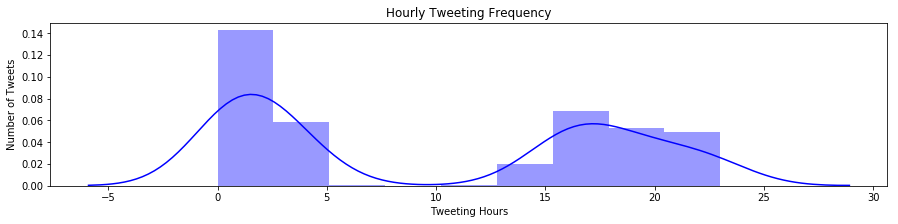

```python
#  define plot size

plt.figure(figsize=(15, 3));

# create plot

ax = sns.distplot((twitter_df['tweet_hour']), hist=True, color='Blue')

#  specfiy axis labels

ax.set(xlabel='Tweeting Hours',
       ylabel='Number of Tweets',
       title='Hourly Tweeting Frequency')

#  display plot

plt.show()
```

Observed a time interval of low to no tweeting activity

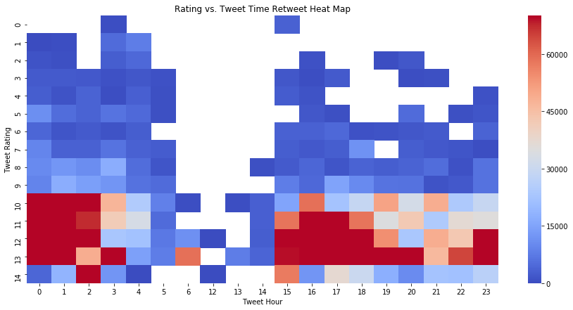

```python
#  define plot size

plt.figure(figsize=(15, 7));

#   aggregate data to plot

plt_data = twitter_df.pivot_table("retweet_count", "rating_numerator","tweet_hour", aggfunc='sum')

#  create plot

ax = sns.heatmap(plt_data, vmin=0, vmax=70000, cmap="coolwarm")

#  specfiy axis labels

ax.set(xlabel="Tweet Hour",
       ylabel="Tweet Rating",
       title="Rating vs. Tweet Time Retweet Heat Map",
       )


#  display plot

plt.show()
```

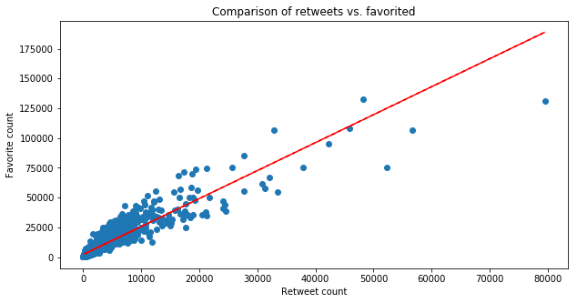

```python
#  define plot size
plt.figure(figsize=(10, 5));


#  scatter plot relationship between retweeted and favorited tweets
plt.scatter(twitter_df['retweet_count'],twitter_df['favorite_count']);
plt.title("Comparison of retweets vs. favorited");
plt.xlabel("Retweet count");
plt.ylabel("Favorite count");


# calc the trendline
fit = np.polyfit(twitter_df['retweet_count'], twitter_df['favorite_count'], 1)
poly_line = np.poly1d(fit)

#  print trend line
plt.plot(twitter_df['retweet_count'],poly_line(twitter_df['retweet_count']),"r--");
```

Linear relationship observed between the number of retweets and the number of favorited tweets

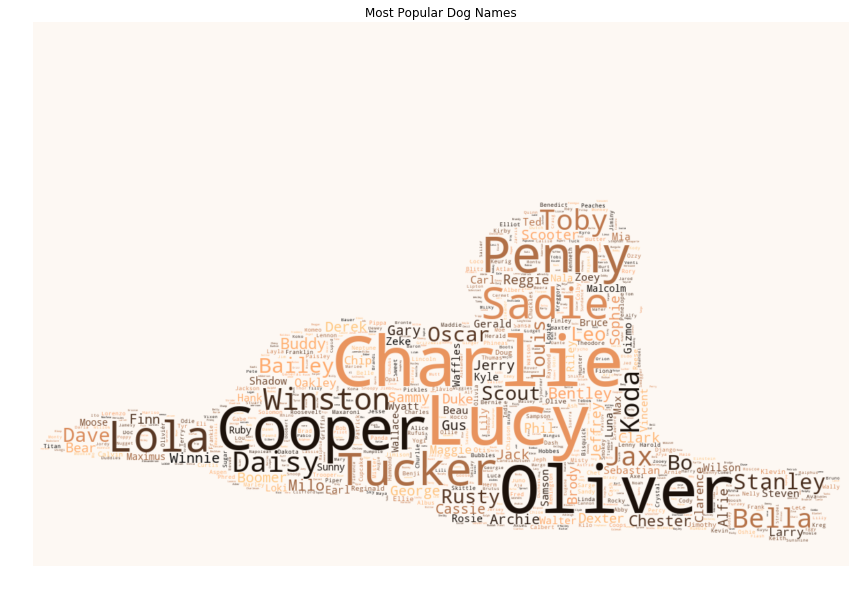

```python
#  creating wordcloud with most frequent names for Dogs
#  Code reference - https://amueller.github.io/word_cloud/auto_examples/masked.html
from os import path
from PIL import Image
import numpy as np
import matplotlib.pyplot as plt
import os

from wordcloud import WordCloud, STOPWORDS, ImageColorGenerator

# get data directory (using getcwd() is needed to support running example in generated IPython notebook)
d = path.dirname(__file__) if "__file__" in locals() else os.getcwd()


#  create the word cloud text excluding NaN
text = []
for name in twitter_df.dog_name.values:
    if name != np.nan:
        text.append(name)
text = ' '.join(map(str, text))
text = text.replace('nan','')


# read the image taken from
# https://th.bing.com/th/id/R.2c1a04313005b9d8cb14ac85d7235e55?rik=UUDLIG4gbpu2Ew&riu=http%3a%2f%2fclipart-library.com%2fimages_k%2fgolden-doodle-silhouette%2fgolden-doodle-silhouette-8.png&ehk=0Idq0MAysi3c8UvjM42EDHKV2%2bl33ARSwiyZgdKf23Y%3d&risl=&pid=ImgRaw&r=0

dog_coloring = np.array(Image.open(path.join(d, "golden-retriever.png")))

wc = WordCloud(width = 480, height = 480, background_color="#fdf8f3", max_words=5000, mask = dog_coloring,
               colormap="copper",max_font_size=100, random_state=42)
# generate word cloud
wc.generate(text)

#  show word cloud


plt.figure(figsize=(15, 10));
plt.axis("off")
plt.title("Most Popular Dog Names");
plt.imshow(wc, interpolation="bilinear");
plt.title("Most Popular Dog Names");
```